# Hands_on 1 - Data Analytics

# Data manipulation :

> by using `dir(data)` we can find some useful methods :
> - .merge()
> - .concat()

Task 7 :

fill below code to merge Iran vs Iraq on date

```python
ir = data[data['country']=='Iran'][['country','date','daily_vaccinations_per_million']].copy()
iq = data[data['country']=='Iraq'][['country','date','daily_vaccinations_per_million']].copy()

pd.merge(ir, iq, on='date' ,how='inner',suffixes=('_ir', '_iq'))
```

|  | country_ir | date | daily_vaccinations_per_million_ir | country_iq | daily_vaccinations_per_million_iq |
| --- | --- | --- | --- | --- | --- |
| 0 | Iran | 2021-03-01 | 45.0 | Iraq | NaN |
| 1 | Iran | 2021-03-02 | 45.0 | Iraq | 23.0 |
| 2 | Iran | 2021-03-03 | 45.0 | Iraq | 23.0 |
| 3 | Iran | 2021-03-04 | 45.0 | Iraq | 23.0 |
| 4 | Iran | 2021-03-05 | 45.0 | Iraq | 23.0 |
| ... | ... | ... | ... | ... | ... |
| 190 | Iran | 2021-09-07 | 5763.0 | Iraq | 4546.0 |
| 191 | Iran | 2021-09-08 | 6591.0 | Iraq | 7755.0 |
| 192 | Iran | 2021-09-09 | 7419.0 | Iraq | 8660.0 |
| 193 | Iran | 2021-09-10 | 8247.0 | Iraq | 9565.0 |
| 194 | Iran | 2021-09-11 | 9075.0 | Iraq | 10469.0 |

195 rows × 5 columns

# Data visualization :

> by using `dir(data)` we can find some useful methods :
> - .plot()
> - .hist()
> - .boxplot()

Task 8 :

Fill below code by a numeric column

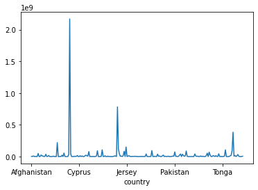

```python
data.groupby('country').sum()['daily_vaccinations'].plot();
```

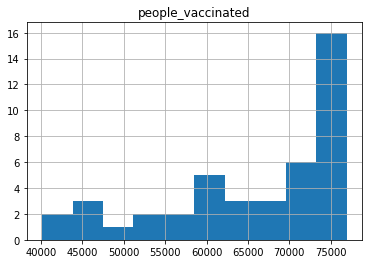

```python
data[data['country']=='Jersey'].loc[:,['date','people_vaccinated']].hist();
```

you can also use matplotlib to for abow plots

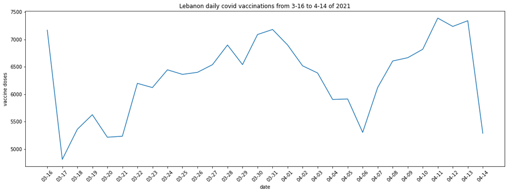

```python
Lebanon = data[(data['country']=='Lebanon') & (data['date']> '2021-03-15') & (data['date'] < '2021-04-15')]
Lebanon = Lebanon.loc[:,['date','daily_vaccinations']]
plt.figure(figsize=[18,6])
plt.plot(Lebanon['date'].str[5:],Lebanon['daily_vaccinations'])
plt.title("Lebanon daily covid vaccinations from 3-16 to 4-14 of 2021")
plt.xlabel('date')
plt.ylabel('vaccine doses')
plt.xticks(rotation=45);
```

$Keep$ $faith$ $in$ $yourself$ $and$ $trust$ $the$ $process$ $...$